# Risk Factor Analysis

## Outcome Variable

**Outcome Variable:** dead

## Predictor Variables

**Intervention Variable:** ever_stunted624

**Adjustment Set:**

unadjusted

## Stratifying Variables

The analysis was stratified on these variable(s):

- studyid
- country

## Data Summary

| studyid | country | ever_stunted624 | dead | n_cell | n |
| --- | --- | --- | --- | --- | --- |
| ki0047075b-MAL-ED | BANGLADESH | 0 | 0 | 92 | 159 |
| ki0047075b-MAL-ED | BANGLADESH | 0 | 1 | 0 | 159 |
| ki0047075b-MAL-ED | BANGLADESH | 1 | 0 | 67 | 159 |
| ki0047075b-MAL-ED | BANGLADESH | 1 | 1 | 0 | 159 |
| ki0047075b-MAL-ED | INDIA | 0 | 0 | 91 | 155 |
| ki0047075b-MAL-ED | INDIA | 0 | 1 | 0 | 155 |
| ki0047075b-MAL-ED | INDIA | 1 | 0 | 64 | 155 |
| ki0047075b-MAL-ED | INDIA | 1 | 1 | 0 | 155 |
| ki0047075b-MAL-ED | PERU | 0 | 0 | 90 | 149 |
| ki0047075b-MAL-ED | PERU | 0 | 1 | 0 | 149 |
| ki0047075b-MAL-ED | PERU | 1 | 0 | 59 | 149 |
| ki0047075b-MAL-ED | PERU | 1 | 1 | 0 | 149 |
| ki0047075b-MAL-ED | SOUTH AFRICA | 0 | 0 | 101 | 159 |
| ki0047075b-MAL-ED | SOUTH AFRICA | 0 | 1 | 0 | 159 |
| ki0047075b-MAL-ED | SOUTH AFRICA | 1 | 0 | 58 | 159 |
| ki0047075b-MAL-ED | SOUTH AFRICA | 1 | 1 | 0 | 159 |
| ki0047075b-MAL-ED | TANZANIA, UNITED REPUBLIC OF | 0 | 0 | 32 | 145 |
| ki0047075b-MAL-ED | TANZANIA, UNITED REPUBLIC OF | 0 | 1 | 0 | 145 |
| ki0047075b-MAL-ED | TANZANIA, UNITED REPUBLIC OF | 1 | 0 | 113 | 145 |
| ki0047075b-MAL-ED | TANZANIA, UNITED REPUBLIC OF | 1 | 1 | 0 | 145 |
| ki1000304-VITAMIN-A | INDIA | 0 | 0 | 1522 | 2759 |
| ki1000304-VITAMIN-A | INDIA | 0 | 1 | 7 | 2759 |
| ki1000304-VITAMIN-A | INDIA | 1 | 0 | 1226 | 2759 |
| ki1000304-VITAMIN-A | INDIA | 1 | 1 | 4 | 2759 |
| ki1000304b-SAS-CompFeed | INDIA | 0 | 0 | 404 | 813 |
| ki1000304b-SAS-CompFeed | INDIA | 0 | 1 | 0 | 813 |
| ki1000304b-SAS-CompFeed | INDIA | 1 | 0 | 407 | 813 |
| ki1000304b-SAS-CompFeed | INDIA | 1 | 1 | 2 | 813 |
| ki1000304b-SAS-FoodSuppl | INDIA | 0 | 0 | 59 | 243 |
| ki1000304b-SAS-FoodSuppl | INDIA | 0 | 1 | 0 | 243 |
| ki1000304b-SAS-FoodSuppl | INDIA | 1 | 0 | 183 | 243 |
| ki1000304b-SAS-FoodSuppl | INDIA | 1 | 1 | 1 | 243 |
| ki1017093b-PROVIDE | BANGLADESH | 0 | 0 | 320 | 457 |
| ki1017093b-PROVIDE | BANGLADESH | 0 | 1 | 0 | 457 |
| ki1017093b-PROVIDE | BANGLADESH | 1 | 0 | 137 | 457 |
| ki1017093b-PROVIDE | BANGLADESH | 1 | 1 | 0 | 457 |
| ki1066203-TanzaniaChild2 | TANZANIA, UNITED REPUBLIC OF | 0 | 0 | 1239 | 1602 |
| ki1066203-TanzaniaChild2 | TANZANIA, UNITED REPUBLIC OF | 0 | 1 | 1 | 1602 |
| ki1066203-TanzaniaChild2 | TANZANIA, UNITED REPUBLIC OF | 1 | 0 | 362 | 1602 |
| ki1066203-TanzaniaChild2 | TANZANIA, UNITED REPUBLIC OF | 1 | 1 | 0 | 1602 |
| ki1101329-Keneba | GAMBIA | 0 | 0 | 1270 | 1989 |
| ki1101329-Keneba | GAMBIA | 0 | 1 | 14 | 1989 |
| ki1101329-Keneba | GAMBIA | 1 | 0 | 703 | 1989 |
| ki1101329-Keneba | GAMBIA | 1 | 1 | 2 | 1989 |
| ki1112895-Burkina Faso Zn | BURKINA FASO | 0 | 0 | 4563 | 7147 |
| ki1112895-Burkina Faso Zn | BURKINA FASO | 0 | 1 | 22 | 7147 |
| ki1112895-Burkina Faso Zn | BURKINA FASO | 1 | 0 | 2545 | 7147 |
| ki1112895-Burkina Faso Zn | BURKINA FASO | 1 | 1 | 17 | 7147 |
| ki1113344-GMS-Nepal | NEPAL | 0 | 0 | 186 | 426 |
| ki1113344-GMS-Nepal | NEPAL | 0 | 1 | 1 | 426 |
| ki1113344-GMS-Nepal | NEPAL | 1 | 0 | 239 | 426 |
| ki1113344-GMS-Nepal | NEPAL | 1 | 1 | 0 | 426 |
| ki1126311-ZVITAMBO | ZIMBABWE | 0 | 0 | 5756 | 7762 |
| ki1126311-ZVITAMBO | ZIMBABWE | 0 | 1 | 78 | 7762 |
| ki1126311-ZVITAMBO | ZIMBABWE | 1 | 0 | 1838 | 7762 |
| ki1126311-ZVITAMBO | ZIMBABWE | 1 | 1 | 90 | 7762 |
| ki1148112-iLiNS-DOSE | MALAWI | 0 | 0 | 805 | 1407 |
| ki1148112-iLiNS-DOSE | MALAWI | 0 | 1 | 10 | 1407 |
| ki1148112-iLiNS-DOSE | MALAWI | 1 | 0 | 578 | 1407 |
| ki1148112-iLiNS-DOSE | MALAWI | 1 | 1 | 14 | 1407 |
| ki1148112-iLiNS-DYAD-M | MALAWI | 0 | 0 | 593 | 972 |
| ki1148112-iLiNS-DYAD-M | MALAWI | 0 | 1 | 7 | 972 |
| ki1148112-iLiNS-DYAD-M | MALAWI | 1 | 0 | 364 | 972 |
| ki1148112-iLiNS-DYAD-M | MALAWI | 1 | 1 | 8 | 972 |
| kiGH5241-JiVitA-3 | BANGLADESH | 0 | 0 | 8177 | 10514 |
| kiGH5241-JiVitA-3 | BANGLADESH | 0 | 1 | 50 | 10514 |
| kiGH5241-JiVitA-3 | BANGLADESH | 1 | 0 | 2269 | 10514 |
| kiGH5241-JiVitA-3 | BANGLADESH | 1 | 1 | 18 | 10514 |
| kiGH5241-JiVitA-4 | BANGLADESH | 0 | 0 | 2255 | 3649 |
| kiGH5241-JiVitA-4 | BANGLADESH | 0 | 1 | 15 | 3649 |
| kiGH5241-JiVitA-4 | BANGLADESH | 1 | 0 | 1365 | 3649 |
| kiGH5241-JiVitA-4 | BANGLADESH | 1 | 1 | 14 | 3649 |

The following strata were considered:

- studyid: ki0047075b-MAL-ED, country: BANGLADESH
- studyid: ki0047075b-MAL-ED, country: INDIA
- studyid: ki0047075b-MAL-ED, country: PERU
- studyid: ki0047075b-MAL-ED, country: SOUTH AFRICA
- studyid: ki0047075b-MAL-ED, country: TANZANIA, UNITED REPUBLIC OF
- studyid: ki1000304-VITAMIN-A, country: INDIA
- studyid: ki1000304b-SAS-CompFeed, country: INDIA
- studyid: ki1000304b-SAS-FoodSuppl, country: INDIA
- studyid: ki1017093b-PROVIDE, country: BANGLADESH
- studyid: ki1066203-TanzaniaChild2, country: TANZANIA, UNITED REPUBLIC OF
- studyid: ki1101329-Keneba, country: GAMBIA
- studyid: ki1112895-Burkina Faso Zn, country: BURKINA FASO
- studyid: ki1113344-GMS-Nepal, country: NEPAL
- studyid: ki1126311-ZVITAMBO, country: ZIMBABWE
- studyid: ki1148112-iLiNS-DOSE, country: MALAWI
- studyid: ki1148112-iLiNS-DYAD-M, country: MALAWI
- studyid: kiGH5241-JiVitA-3, country: BANGLADESH
- studyid: kiGH5241-JiVitA-4, country: BANGLADESH

### Dropped Strata

Some strata were dropped due to rare outcomes:

- studyid: ki0047075b-MAL-ED, country: BANGLADESH
- studyid: ki0047075b-MAL-ED, country: INDIA
- studyid: ki0047075b-MAL-ED, country: PERU
- studyid: ki0047075b-MAL-ED, country: SOUTH AFRICA
- studyid: ki0047075b-MAL-ED, country: TANZANIA, UNITED REPUBLIC OF
- studyid: ki1000304-VITAMIN-A, country: INDIA
- studyid: ki1000304b-SAS-CompFeed, country: INDIA
- studyid: ki1000304b-SAS-FoodSuppl, country: INDIA
- studyid: ki1017093b-PROVIDE, country: BANGLADESH
- studyid: ki1066203-TanzaniaChild2, country: TANZANIA, UNITED REPUBLIC OF
- studyid: ki1101329-Keneba, country: GAMBIA
- studyid: ki1113344-GMS-Nepal, country: NEPAL

## Methods Detail

We’re interested in the causal parameters $E[Y_a]$ for all values of $a \in \mathcal{A}$. These parameters represent the mean outcome if, possibly contrary to fact, we intervened to set all units to have $A=a$. Under the randomization and positivity assumptions, these are identified by the statistical parameters $\psi_a=E_W[E_{Y|A,W}(Y|A=a,W)]$. In addition, we’re interested in the mean of $Y$, $E[Y]$ under no intervention (the observed mean). We will estimate these parameters by using SuperLearner to fit the relevant likelihood factors – $E_{Y|A,W}(Y|A=a,W)$ and $p(A=a|W)$, and then updating our likelihood fit using a joint TMLE.

For unadjusted analyses ($W=\{\}$), initial likelihoods were estimated using Lrnr_glm to estimate the simple $E(Y|A)$ and Lrnr_mean to estimate $p(A)$. For adjusted analyses, a small library containing Lrnr_glmnet, Lrnr_xgboost, and Lrnr_mean was used.

Having estimated these parameters, we will then use the delta method to estimate relative risks and attributable risks relative to a prespecified baseline level of $A$.

# Results Detail

## Results Plots

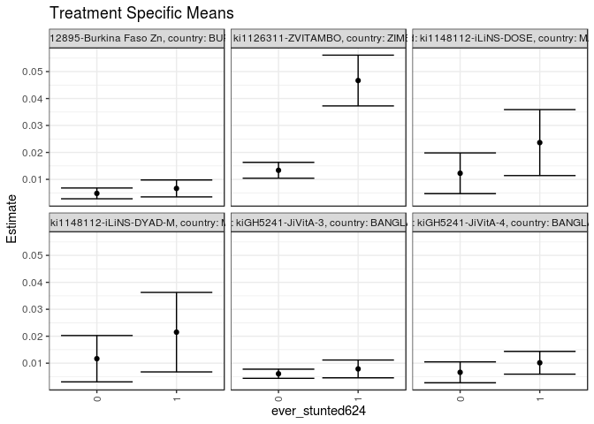

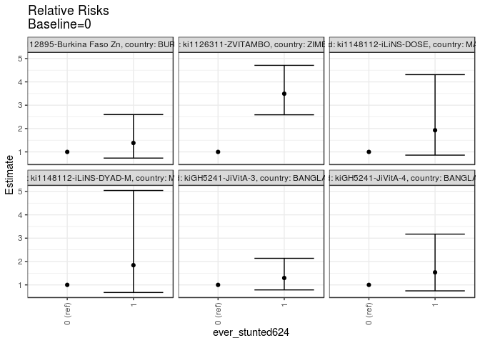

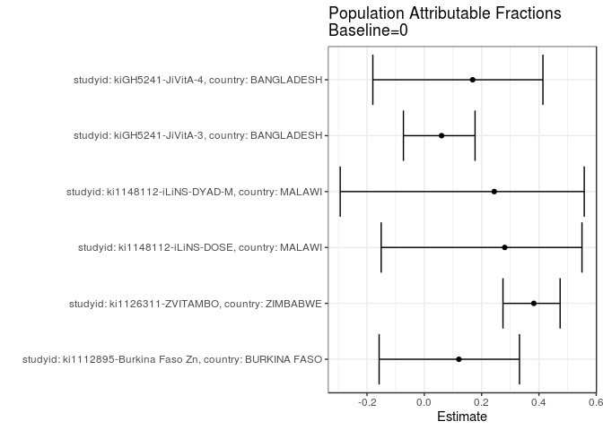

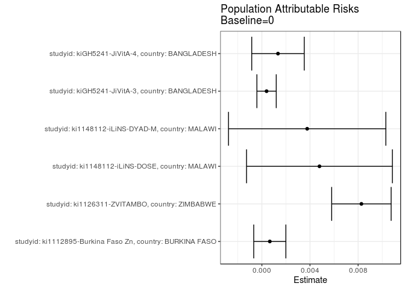

## Results Table

### Parameter: TSM

| studyid | country | intervention_level | baseline_level | estimate | ci_lower | ci_upper |
| --- | --- | --- | --- | --- | --- | --- |
| ki1112895-Burkina Faso Zn | BURKINA FASO | 0 | NA | 0.0047983 | 0.0027979 | 0.0067986 |
| ki1112895-Burkina Faso Zn | BURKINA FASO | 1 | NA | 0.0066354 | 0.0034915 | 0.0097794 |
| ki1126311-ZVITAMBO | ZIMBABWE | 0 | NA | 0.0133699 | 0.0104225 | 0.0163173 |
| ki1126311-ZVITAMBO | ZIMBABWE | 1 | NA | 0.0466805 | 0.0372636 | 0.0560974 |
| ki1148112-iLiNS-DOSE | MALAWI | 0 | NA | 0.0122699 | 0.0047092 | 0.0198307 |
| ki1148112-iLiNS-DOSE | MALAWI | 1 | NA | 0.0236486 | 0.0114040 | 0.0358933 |
| ki1148112-iLiNS-DYAD-M | MALAWI | 0 | NA | 0.0116667 | 0.0030702 | 0.0202632 |
| ki1148112-iLiNS-DYAD-M | MALAWI | 1 | NA | 0.0215054 | 0.0067567 | 0.0362540 |
| kiGH5241-JiVitA-3 | BANGLADESH | 0 | NA | 0.0060775 | 0.0043813 | 0.0077738 |
| kiGH5241-JiVitA-3 | BANGLADESH | 1 | NA | 0.0078706 | 0.0045615 | 0.0111797 |
| kiGH5241-JiVitA-4 | BANGLADESH | 0 | NA | 0.0066079 | 0.0027303 | 0.0104856 |
| kiGH5241-JiVitA-4 | BANGLADESH | 1 | NA | 0.0101523 | 0.0059324 | 0.0143722 |

### Parameter: E(Y)

| studyid | country | intervention_level | baseline_level | estimate | ci_lower | ci_upper |
| --- | --- | --- | --- | --- | --- | --- |
| ki1112895-Burkina Faso Zn | BURKINA FASO | NA | NA | 0.0054568 | 0.0037488 | 0.0071649 |
| ki1126311-ZVITAMBO | ZIMBABWE | NA | NA | 0.0216439 | 0.0184064 | 0.0248814 |
| ki1148112-iLiNS-DOSE | MALAWI | NA | NA | 0.0170576 | 0.0102893 | 0.0238258 |
| ki1148112-iLiNS-DYAD-M | MALAWI | NA | NA | 0.0154321 | 0.0076790 | 0.0231852 |
| kiGH5241-JiVitA-3 | BANGLADESH | NA | NA | 0.0064676 | 0.0049483 | 0.0079868 |
| kiGH5241-JiVitA-4 | BANGLADESH | NA | NA | 0.0079474 | 0.0050813 | 0.0108134 |

### Parameter: RR

| studyid | country | intervention_level | baseline_level | estimate | ci_lower | ci_upper |
| --- | --- | --- | --- | --- | --- | --- |
| ki1112895-Burkina Faso Zn | BURKINA FASO | 0 | 0 | 1.000000 | 1.0000000 | 1.000000 |
| ki1112895-Burkina Faso Zn | BURKINA FASO | 1 | 0 | 1.382886 | 0.7356976 | 2.599403 |
| ki1126311-ZVITAMBO | ZIMBABWE | 0 | 0 | 1.000000 | 1.0000000 | 1.000000 |
| ki1126311-ZVITAMBO | ZIMBABWE | 1 | 0 | 3.491462 | 2.5895945 | 4.707419 |
| ki1148112-iLiNS-DOSE | MALAWI | 0 | 0 | 1.000000 | 1.0000000 | 1.000000 |
| ki1148112-iLiNS-DOSE | MALAWI | 1 | 0 | 1.927365 | 0.8618253 | 4.310311 |
| ki1148112-iLiNS-DYAD-M | MALAWI | 0 | 0 | 1.000000 | 1.0000000 | 1.000000 |
| ki1148112-iLiNS-DYAD-M | MALAWI | 1 | 0 | 1.843318 | 0.6736472 | 5.043918 |
| kiGH5241-JiVitA-3 | BANGLADESH | 0 | 0 | 1.000000 | 1.0000000 | 1.000000 |
| kiGH5241-JiVitA-3 | BANGLADESH | 1 | 0 | 1.295024 | 0.7845420 | 2.137664 |
| kiGH5241-JiVitA-4 | BANGLADESH | 0 | 0 | 1.000000 | 1.0000000 | 1.000000 |
| kiGH5241-JiVitA-4 | BANGLADESH | 1 | 0 | 1.536379 | 0.7438581 | 3.173267 |

### Parameter: PAR

| studyid | country | intervention_level | baseline_level | estimate | ci_lower | ci_upper |
| --- | --- | --- | --- | --- | --- | --- |
| ki1112895-Burkina Faso Zn | BURKINA FASO | 0 | NA | 0.0006586 | -0.0006774 | 0.0019945 |
| ki1126311-ZVITAMBO | ZIMBABWE | 0 | NA | 0.0082740 | 0.0058022 | 0.0107458 |
| ki1148112-iLiNS-DOSE | MALAWI | 0 | NA | 0.0047876 | -0.0012745 | 0.0108498 |
| ki1148112-iLiNS-DYAD-M | MALAWI | 0 | NA | 0.0037654 | -0.0027749 | 0.0103057 |
| kiGH5241-JiVitA-3 | BANGLADESH | 0 | NA | 0.0003900 | -0.0004139 | 0.0011939 |
| kiGH5241-JiVitA-4 | BANGLADESH | 0 | NA | 0.0013395 | -0.0008436 | 0.0035225 |

### Parameter: PAF

| studyid | country | intervention_level | baseline_level | estimate | ci_lower | ci_upper |
| --- | --- | --- | --- | --- | --- | --- |
| ki1112895-Burkina Faso Zn | BURKINA FASO | 0 | NA | 0.1206890 | -0.1577837 | 0.3321828 |
| ki1126311-ZVITAMBO | ZIMBABWE | 0 | NA | 0.3822788 | 0.2745434 | 0.4740146 |
| ki1148112-iLiNS-DOSE | MALAWI | 0 | NA | 0.2806748 | -0.1507032 | 0.5503370 |
| ki1148112-iLiNS-DYAD-M | MALAWI | 0 | NA | 0.2440000 | -0.2936939 | 0.5582139 |
| kiGH5241-JiVitA-3 | BANGLADESH | 0 | NA | 0.0603036 | -0.0730004 | 0.1770466 |
| kiGH5241-JiVitA-4 | BANGLADESH | 0 | NA | 0.1685402 | -0.1797649 | 0.4140142 |